# Project Two: Predicting Iris Flowers

[figure not shown]

## Introduction

Flowers play an essential role in our lives, from expressing emotions to contributing to environmental sustainability. Among them, the Iris flower holds a special place—not just in nature, but also in the world of data science. The Iris dataset is one of the most well-known datasets, first introduced in R.A. Fisher's 1936 paper, *The Use of Multiple Measurements in Taxonomic Problems*. This dataset has since become a fundamental resource in machine learning and statistical classification. It is widely used for testing algorithms and can be accessed through the UCI Machine Learning Repository.

The dataset itself is straightforward with only 4 features and 150 rows. The dataset is evenly distributed among the three species (50 samples per class). Here are all the features in detail:

| **Feature** | **Description** |
| --- | --- |
| Id | Row Number |
| SepalLengthCm | Length of the sepal |
| SepalWidthCm | Width of the sepal |
| PetalLengthCm | Length of the Petal |
| PetalWidthCm | Width of the Petal |
| Species | Species of the iris. Either being Iris-setosa, Iris-versicolor, or Iris-virginica |

As a little refresher, the sepal is the leaf-like part that encloses and protects the flower bud, and the petal is the modified leaf that surrounds the reproductive parts of a flower and usually contains the color.

```python
#Imports
import numpy as np
import pandas as pd
import matplotlib.pyplot as plt
import seaborn as sns
from sklearn import tree
from sklearn.model_selection import train_test_split
from sklearn.metrics import accuracy_score, classification_report
from sklearn.neighbors import KNeighborsClassifier
from sklearn import datasets
```

```python
#dataset
df = pd.read_csv('iris.csv')
df.head()
```

|  | Id | SepalLengthCm | SepalWidthCm | PetalLengthCm | PetalWidthCm | Species |
| --- | --- | --- | --- | --- | --- | --- |
| 0 | 1 | 5.1 | 3.5 | 1.4 | 0.2 | Iris-setosa |
| 1 | 2 | 4.9 | 3.0 | 1.4 | 0.2 | Iris-setosa |
| 2 | 3 | 4.7 | 3.2 | 1.3 | 0.2 | Iris-setosa |
| 3 | 4 | 4.6 | 3.1 | 1.5 | 0.2 | Iris-setosa |
| 4 | 5 | 5.0 | 3.6 | 1.4 | 0.2 | Iris-setosa |

## Pre-processing

Since this dataset is so popular for machine learning and it's so small with little features, it seems likely this data is already clean. Though let's just make sure kaggle didn't have any import errors and/or the dataset wasn't poorly uploaded.

### Dropping nulls

```python
df.isnull().sum()
```

```
Id               0
SepalLengthCm    0
SepalWidthCm     0
PetalLengthCm    0
PetalWidthCm     0
Species          0
dtype: int64
```

No nulls are here so we don't have to worry about it.

### Duplicates

```python
print(df.duplicated().value_counts())
```

```
False    150
Name: count, dtype: int64
```

No duplicates either which is nice

### Id Column

There is an Id column which dataframe already tracks and the column will mess up some visualizaions and modeling. We'll just remove it from the dataset.

```python
df = df.drop("Id", axis=1)
```

### Checking for unusual types

```python
df.dtypes
```

```
SepalLengthCm    float64
SepalWidthCm     float64
PetalLengthCm    float64
PetalWidthCm     float64
Species           object
dtype: object
```

Types also aren't an issue which should confirm the db looks okay, for now.

## Pre-Modeling Visualization

To visualize the iris dataset, let's look they each species compare to eachothers attributes.

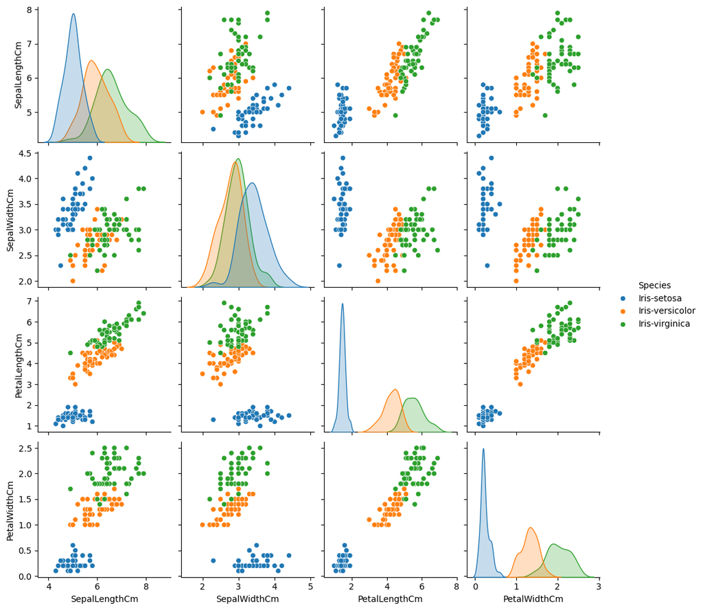

```python
sns.pairplot(df, hue='Species', diag_kind='kde')
plt.show()
```

An exciting thing to see is how organized this data seems. Setsoa seems very defined in its cluster while Virginica and Versicolor are a little closer together. I'd assume when we start predicting on this dataset, Setsoa predictions will have a higher accuracy if we use k-Nearest Neighbors.

## Modeling & Evaluation

### k-Nearest Neighbors

As this is a classification issue, we'll need a classification model. As mentioned before, the clustering of the data seems like k-Nearest Neighbors (KNN) would be good for a dataset like this. First, we'll create an X and y variable for the species, then we'll split the data with 80% for training and 20% for testing. Then we'll train the model with k=3 as our parameter.

```python
X = df.drop(columns = ["Species"])
y = df["Species"]
```

```python
X_train, X_test, y_train, y_test = sk.model_selection.train_test_split(X, y, test_size=0.2, random_state=42)
```

```python
X_train.shape, X_test.shape, y_train.shape, y_test.shape
```

```
((120, 4), (30, 4), (120,), (30,))
```

Cool, now that we have everything set up lets use the KNN algorithm to predict on the dataset

```python
# Initialize KNN with k=3 (you can change this value)
knn = KNeighborsClassifier(n_neighbors=3)

# Train the model
knn.fit(X_train, y_train)

# Prediction
y_pred = knn.predict(X_test)

# Accuracy score
accuracy = accuracy_score(y_test, y_pred)
print(f"Accuracy: {accuracy:.2f}")
```

```
Accuracy: 1.00
```

```python
print(classification_report(y_test, y_pred))
```

```
                 precision    recall  f1-score   support

    Iris-setosa       1.00      1.00      1.00        10
Iris-versicolor       1.00      1.00      1.00         9
 Iris-virginica       1.00      1.00      1.00        11

       accuracy                           1.00        30
      macro avg       1.00      1.00      1.00        30
   weighted avg       1.00      1.00      1.00        30
```

Strangely, this accuracy is 100%, but keep in mind this dataset is small and well-defined as shown in the previous graph. Just for curiosity's sake, let's find where k is a different value.

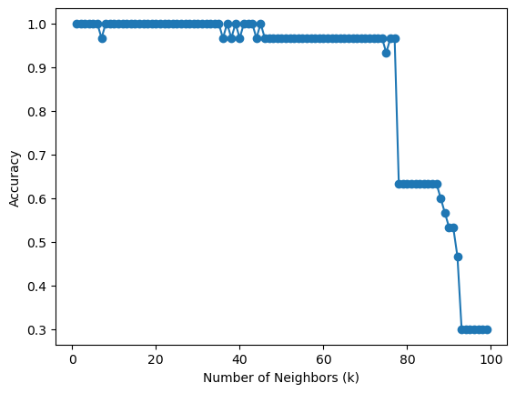

```python
import matplotlib.pyplot as plt

# Try different k values
k_values = range(1, 100)
accuracies = []

for k in k_values:
    knn = KNeighborsClassifier(n_neighbors=k)
    knn.fit(X_train, y_train)
    y_pred = knn.predict(X_test)
    accuracies.append(accuracy_score(y_test, y_pred))

plt.plot(k_values, accuracies, marker='o')
plt.xlabel('Number of Neighbors (k)')
plt.ylabel('Accuracy')
plt.show()
```

So as k gets bigger, the accuracy gets smaller, which would be underfitting the data. This pretty much all means the model is working well and while most options near our first choice will give us 100% accuracy, k=3 seems like a good pick.

### Decision Tree

Let's use another classification model, a decision tree, to see if we'll have similar results.

```python
clf = tree.DecisionTreeClassifier()
clf.fit(X_train, y_train)

y_pred = clf.predict(X_test)

accuracy = accuracy_score(y_test, y_pred)
print(f"Accuracy: {accuracy:.2f}")
```

```
Accuracy: 1.00
```

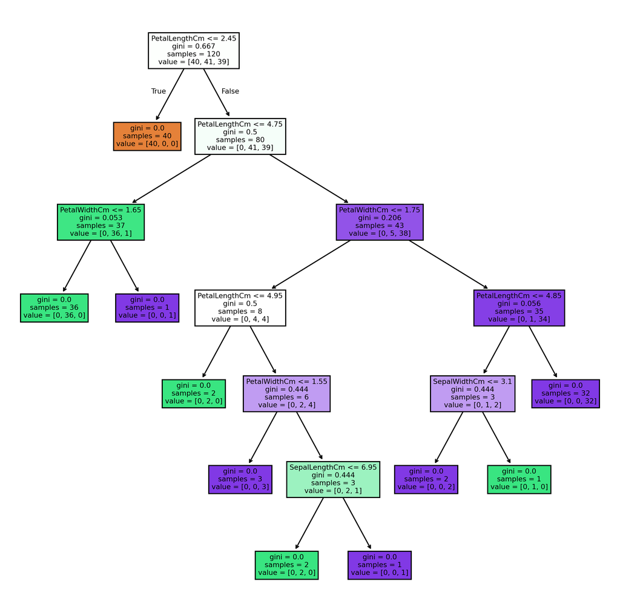

```python
fig, axes = plt.subplots(nrows = 1,ncols = 1, figsize = (10,10), dpi=300)
tree.plot_tree(clf, max_depth = 7, feature_names = X.columns, filled=True)
plt.show()
```

```python
print(classification_report(y_test, y_pred))
```

```
                 precision    recall  f1-score   support

    Iris-setosa       1.00      1.00      1.00        10
Iris-versicolor       1.00      1.00      1.00         9
 Iris-virginica       1.00      1.00      1.00        11

       accuracy                           1.00        30
      macro avg       1.00      1.00      1.00        30
   weighted avg       1.00      1.00      1.00        30
```

Decision Tree is also 100%, which applying the same logic as KNN makes sense. You don't even need to tune parameters and still performs as good as it does.

## Storytelling

Some takeaways from the data gathered:

Overall, I think this project went well. Scikit-learn made doing all the calcuations way easier to understand and do, espically knowning how complicated the math can be sometimes.

I'm very happy that the models do work and give the accuracy they should, however, it is a little disappointing that they're *too perfect*. Next project for regression, I'll be using a way larger dataset to hopefully make things more interesting.

## Impact & Implications

As for the impact of this project, flowers are needed just about anywhere. This project gives more insight to flower growth and how iris speicis differ from eachother, that be by physical appearance.

Of course the benefical implication would be the education it provides. This dataset has been around for so long for machine learning, but it's only known as a machine learning dataset. There may be something to be shown in other fields about this, espically when considering for flower repopulation.

There are some negative implications as well. Popularizing bigger flowers may lead to an overpopulation of a certain species, offsetting the balance. While it may be a small change, it may result in a Mandela effect throughout the environment, affecting animals later in the food chain.

## References

- [Iris Dataset](https://www.kaggle.com/datasets/uciml/iris)
- [Introduction facts](https://www.geeksforgeeks.org/iris-dataset/)